# Slow Learning for Quadratic Classification

## Overview of Topics

- Introduction to the Problem
- Four HLDR Techniques
- Two Dimension Reduction Methods
- Simulation Study
- Real Data Cases
- Conclusion
- References

## Introduction

## Introduction

- We want to classify observations from different elliptical distributions.
- Real examples are often poorly posed (\(n_i < p ^ 2 / 2\)), thus precision matrix estimates are unstable.
- We introduce a competitor to PCA which uses the bias-variance tradeoff to stabilize these covariance estimates.
- We employ linear dimension reduction to break the *curse of dimensionality* via iterated application of the singular value decomposition.

## Four HLDR Techniques

## Four HLDR Techniques

- SY from Ounpraseuth et al. (2015)
- Sliced Inverse Regression (SIR) from Li (1991)
- LD from Loog and Duin (2004)
- Sliced Average Variance Estimation (SAVE) from Cook and Weisberg (1991)

## Notation

Consider a data matrix \(\textbf{X}\) containing \(n\) observations from \(K\) distinct \(p\)-dimensional multivariate normal distributions, with class means \(\boldsymbol\mu_k\) and class covariances \(\boldsymbol\Sigma_k\), for \(k \in 1, \ldots, K\). Furthermore, define

- \(\bar{\textbf{x}}_k\) is the sample mean vector for the \(k^{th}\) class
- \(\alpha_k\) is the *a priori* probability of class membership for the \(k^{th}\) class
- \(\bar{\textbf{x}} := \sum^K_{k = 1}\alpha_k\bar{\textbf{x}}_k\) is the grand mean
- \(\textbf{S}_W := \sum_{k = 1}^K\alpha_k\textbf{S}_k\) is the sample within-class covariance
- \(\textbf{S}_B := \sum^K_{k = 1}\left( \bar{\textbf{x}}_k - \bar{\textbf{x}} \right) \left( \bar{\textbf{x}}_k - \bar{\textbf{x}} \right)^T\) is the sample between-class covariance
- \(\widehat{\boldsymbol\Gamma} := \textbf{S}_B + \textbf{S}_W\) is the estimated marginal covariance of the data matrix

## A Dimension Reduction Result

*Theorem 1:*

Suppose we have \(K\) multivariate normal populations each with mean \(\boldsymbol\mu_k\), covariance matrix \(\boldsymbol\Sigma_k \in \mathbb{R}^>_{p}\), and class membership \(\alpha_k\), where \(k = 1,...,K\). Also, let \[ \textbf{M} := \left[\boldsymbol\Sigma^{-1}_2 \boldsymbol\mu_2 - \boldsymbol\Sigma^{-1}_1 \boldsymbol\mu_1 |...| \boldsymbol\Sigma^{-1}_K \boldsymbol\mu_K - \boldsymbol\Sigma^{-1}_1 \boldsymbol\mu_1 | \boldsymbol\Sigma_2 - \boldsymbol\Sigma_1 |...| \boldsymbol\Sigma_K - \boldsymbol\Sigma_1\right], \] where rank\((\textbf{M}) = q < p\), and let \(\textbf{M} = \textbf{FG}\) be a full-rank decomposition of \(\textbf{M}\), where \(\textbf{F} \in \mathbb{R}_{p \times q}\). Then, for an unlabeled observation vector \(\textbf{x} \in \mathbb{R}_{p \times 1}\), \(d_k(\textbf{x}) = d_k\left( \textbf{F}^+ \textbf{x} \right)\), where \(d_k(\textbf{x})\) is the quadtratic discriminant function for the \(k^{th}\) class and \(k = 1,...,K\).

*Proof:* See Ounpraseuth et al. (2015).

## Two Simpler Methods

### SIR

The data summary matrix for the *SIR LDR* method of Li (1991) is \[ \textbf{M} := \widehat{\boldsymbol\Gamma}^{-1/2}\textbf{S}_B\widehat{\boldsymbol\Gamma}^{-1/2}. \]

## Loog and Duin (2004)

The data summary matrix for the *LD LDR* method is \[ \textbf{M} := \sum^{K - 1}_{i = 1} \sum^K_{j = i + 1} \alpha_i \alpha_j \textbf{S}^{-1}_W \textbf{S}^{1/2}_W \left[ \tilde{\textbf{S}}^*_{ij} \right] \textbf{S}^{1/2}_W, \] where \[ \begin{aligned} \tilde{\textbf{S}}^*_{ij} &:= \left( \textbf{S}^*_{(i,j)} \right)^{-\frac{1}{2}} \textbf{S}^{-1/2}_W \left( \bar{\textbf{x}}_i - \bar{\textbf{x}}_j \right) \left( \bar{\textbf{x}}_i - \bar{\textbf{x}}_j \right)^T \textbf{S}^{-1/2}_W \left( \textbf{S}^*_{(i,j)} \right)^{-\frac{1}{2}} \\ &\qquad + \frac{1}{\pi_i \pi_j} \left[ \log\left( \textbf{S}^*_{(i,j)} \right) - \pi_i \log\left( \textbf{S}^*_{(i,i)} \right) - \pi_j \log\left( \textbf{S}^*_{(j,j)} \right) \right] \end{aligned} \] and \(\textbf{S}^*_{(i,j)} = \textbf{S}^{-1/2}_W \left( \pi_i\textbf{S}_i + \pi_j\textbf{S}_j \right) \textbf{S}^{-1/2}_W\).

## Sliced Average Variance Estimation (1991)

Using the notation modification of Velilla (2008) to Cook and Weisberg's original work, the data summary matrix for the *SAVE LDR* method is \[ \textbf{M} := \left( \widehat{\boldsymbol\Gamma}^{-1/2} \textbf{S}_B \widehat{\boldsymbol\Gamma}^{-1/2} \right)^2 + \widehat{\boldsymbol\Gamma}^{-1/2} \textbf{S}_{\widehat{\boldsymbol\Gamma}} \widehat{\boldsymbol\Gamma}^{-1/2}, \] where \[ \textbf{S}_{\widehat{\boldsymbol\Gamma}} := \frac{1}{K}\sum_{k = 1}^{K} \left( \textbf{S}_k - \textbf{S}_W \right) \widehat{\boldsymbol\Gamma}^{-1} \left( \textbf{S}_k - \textbf{S}_W \right). \]

## Current vs. Slow Learning Algorithms

## PCA

The Principal Components Analysis (*PCA*) Algorithm for dimension reduction (using the Singular Value Decomposition of Eckart and Young (1936)) is as follows:

1. Whiten the \(n \times p\) data matrix \(\textbf{X}\).
2. Construct the appropriate \(\textbf{M}\).
3. Calculate the *SVD* of \(\textbf{M} = \textbf{UDV}^T\).
4. Choose a target dimension \(q\) such that the largest \(q\) singular values of \(\textbf{M}\) account for at least \((1 - \alpha)\)% of the sum of all singular values (energy) of \(\textbf{M}\).
5. Select the first \(q\) singular vectors of \(\textbf{U}\) to be the \(p \times q\) projection matrix.
6. Multiply the \(n \times p\) data matrix by the \(p \times q\) projection matrix to linearly reduce the data from \(p\) to \(q\) dimensions, while preserving \((1 - \alpha)\)% of the energy of the data matrix.

## Slow Learning

The Slow Learning Linear Dimension Reduction (*SLLDR*) Algorithm is as follows:

1. Whiten the \(n \times p\) data matrix \(\textbf{X}\).
2. Construct the appropriate \(\textbf{M}\).
3. Take the *SVD* of \(\textbf{M} = \textbf{UDV}^T\).
4. Choose a target dimension \(q_i\) such that the largest \(q_i\) singular values of \(\textbf{M}\) account for at least \((1 - \alpha / \text{steps})\)% of the energy of \(\textbf{M}\).
5. Select the first \(q_i\) singular vectors of \(\textbf{U}\) to be the \(p \times q_i\) projection matrix.
6. Multiply the \(n \times p\) data matrix by the \(p \times q_i\) projection matrix to linearly reduce the data from \(p\) to \(q_i\) dimensions.
7. Repeat Steps 2 – 6.

## The Algorithm in Detail

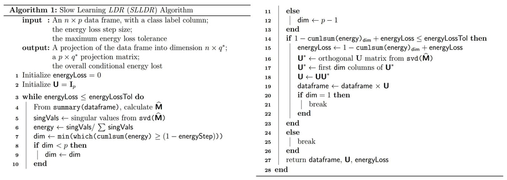

The difference of note between the PCA and Slow Learning algorithms: Slow Learning takes a few smaller "jumps" in dimension reduction rather than one large jump.

## A Projection Matrix Result

*Theorem 2:*

Suppose we have a sequence of subspace projection matrices \(\textbf{U}_{p \times q_1}^{(1)}, \ldots, \textbf{U}_{q_{i - 1} \times q_i}^{(i)}\). Then the composition of the \(i\) linear mappings can be represented by the chain of projection matrix multiplication \[ \textbf{U}^*_{p \times q_i} = \textbf{U}_{p \times q_1}^{(1)} \times \ldots \times \textbf{U}_{q_{i - 1} \times q_i}^{(i)}. \]

## A Projection Matrix Result

*Proof:*

Let \(\textbf{X} \in \mathbb{R}_{n \times p}\) be an arbitrary matrix signifying a data frame of \(n\) observations in \(p\) dimensions. Let \(\textbf{M}^{(1)} = \textbf{U}^{(1)}\textbf{DV}^T\) be the *SVD* of an \(\textbf{M}\) matrix of \(\textbf{X}\). Then by Theorem 1, the linear projection preserving *essentially* all the classification information of \(\textbf{X}\) is the first \(q_1\) columns of the matrix \(\textbf{U}^{(1)}\). Now let \(\textbf{M}^{(2)} = \textbf{U}^{(2)}\textbf{DV}^T\) be the *SVD* of the \(\textbf{M}\) matrix of \(\textbf{X}^{(1)}_{n \times q_1} = \textbf{X}\textbf{U}^{(1)}_{p \times q_1}\). Similarly, \[ \begin{aligned} \textbf{X}^{(2)}_{n \times q_2} &= \textbf{X} \times \textbf{U}^{(1)}_{p \times q_1} \times \textbf{U}^{(2)}_{q_1 \times q_2} \\ &\vdots \\ \Longrightarrow\qquad \textbf{X}^{(i)}_{n \times q_i} &= \textbf{X} \times \textbf{U}^{(1)}_{p \times q_1} \times \textbf{U}^{(2)}_{q_1 \times q_2} \times \ldots \times \textbf{U}_{q_{i - 1} \times q_i}^{(i)} \\ &= \textbf{X} \times \textbf{U}^*_{p \times q_i}. \end{aligned} \]

## Simulation Study

## Simulation Setup

1. For each class, generate 5,000 observations from the designated 10-dimensional multivariate normal distribution.
2. Partition the 5,000 observations from each class into a training and testing data set
   1. To simulate poorly-posed scenarios, take \(n = 15\) training observations per class.
   2. Hold 4,985 observations aside for testing.

## Simulation Setup

3. For each method:
   1. Project the training and test data down from \(p\) to \(r\) dimensions, for \(r\in 1,\ldots, p - 1\).
   2. Construct the classifier.
   3. Classify the test observations.
   4. Calculate the conditional error rate.
4. Repeat Steps 1–3 5,000 times.
5. Increase \(n\) from 15 to 30 then 60, and repeat Steps 1–4.

## Synthetic Data Results

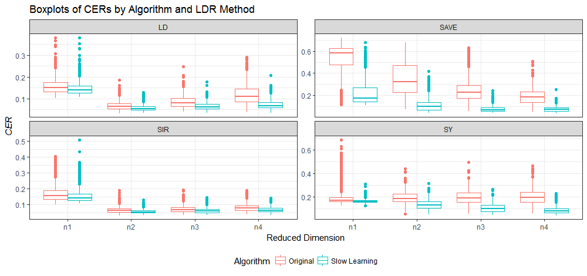

## Ionosphere Returns (Sigillito et al. 1989)

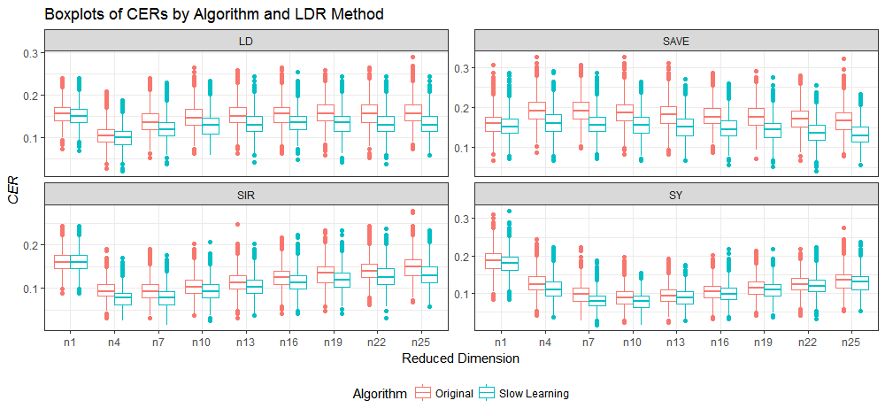

## Self-Driving Car Faults (Paschke et al. 2013)

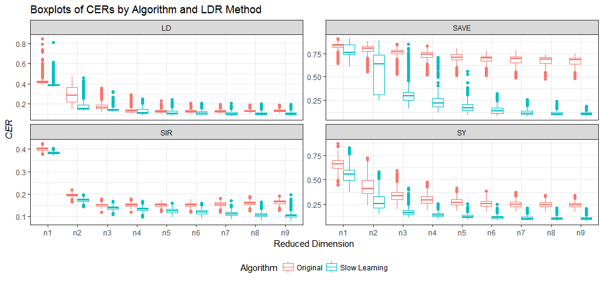

## Summary and References

## Summary

- We discussed four linear dimension reduction methods, and we compared two decompostion algorithms.
- We produced simulation results showing Slow Learning algorithm efficacy when contrasted against the common approach.
- We further applied our algorithm to two real-world classification exercises, showing the viability of Slow Learning as a dimension reduction strategy.

We give special thanks to Bache and Lichman (2013) for managing the UC-Irvine Machine Learning Repository—a wealth of real machine learning data.

## References

Bache, Kevin, and Moshe Lichman. 2013. *UCI Machine Learning Repository*. University of California, Irvine, School of Information; Computer Sciences.

Cook, R. Dennis, and Sanford Weisberg. 1991. “Sliced Inverse Regression for Dimension Reduction: Comment.” *J. Am. Stat. Assoc.* 86 (414): 328–32. doi:10.2307/2290564.

Eckart, Carl, and Gale Young. 1936. “The Approximation of One Matrix by Another of Lower Rank.” *Psychometrika* 1 (3): 211–18. doi:10.1007/BF02288367.

Li, Ker-Chau. 1991. “Sliced Inverse Regression for Dimension Reduction.” *J. Am. Stat. Assoc.* 86 (414): 316–27. doi:10.2307/2290563.

Loog, Marco, and Robert P. W. Duin. 2004. “Linear Dimensionality Reduction via a Heteroscedastic Extension of LDA: The Chernoff Criterion.” *IEEE Trans. Pattern. Anal. Mach. Intell.* 26 (6): 732–39. doi:10.1109/TPAMI.2004.13.

Ounpraseuth, Songthip T., Phil D. Young, Johanna S. Van Zyl, Tyler W. Nelson, and Dean M. Young. 2015. “Linear Dimension Reduction for Multiple Heteroscedastic Multivariate Normal Populations.” *OJS* 05 (04): 311. doi:10.4236/ojs.2015.54033.

Paschke, Fabian, Christian Bayer, Martyna Bator, Uwe Mönks, Alexander Dicks, Olaf Enge-Rosenblatt, and Volker Lohweg. 2013. “Sensorlose Zustandsüberwachung an Synchronmotoren.” In *ResearchGate*.

Sigillito, V. G., S. P. Wing, L. V. Hutton, and K. B. Baker. 1989. “Classification of Radar Returns from the Ionosphere Using Neural Networks.” *J. Hopkins Apl. Tech. D.* vol. 10: 262–66.

Velilla, Santiago. 2008. “A Method for Dimension Reduction in Quadratic Classification Problems.” *J. Comput. Graph. Stat.* 17 (3): 572–89.